# Effect of VK001 on Viral Replication

by Hakjun Lee

```css
/* Whole Document: */
body{
  font-family: Times New Roman;
  font-size: 12pt;
  color: grey;
}
/* Headers */
  h1,h2,h3,h4{
    color: black;
  }
```

```r
#downloading package 'ggplot2' from CRAN, an external repository. This is necessary as 'ggplot2' is outside the default library.
install.packages("ggplot2", repos = "http://cran.us.r-project.org")
#loading all required packages
library(ggplot2)
library(psych)
library(pwr)

#loading data file
load("STAT_ICA1_21.rdata")
```

## Aim

The aim of this report is to determine for which viruses the drug VK001 is effective against.

## Introduction

#### Background

A novel anti-viral drug, VK001, is suggested to slow the spread of potentially zoonotic viruses, should the viruses succeed in interspecies transmission. VK001 can inhibit viral replication by binding to viral genetic material, reducing the replication rate of viruses.

However, the sequence to which VK001 binds to most likely limits which type of virus it is effective against. In order to determine viable candidates for this drug, it is tested on various viral classes. Viruses similar to other viruses that had crossed the species barrier previously are selected.

#### Experimental Procedure

Macaques were infected with different candidate viruses at day one. Starting at day six, they were treated with two doses of VK001 per day. Blood samples were also taken at day six and at day eight, from which viral load was determined.

A type of virus that was already shown to be inhibited by VK001 was used as a positive control. A virus particle without any genetic material and thus incapable of replicating was used as a negative control.

#### Null Hypothesis

VK001 does not have an effect on viral load for the virus type.

#### Alternative Hypothesis

VK001 reduces the viral load for the virus type.

## Data Analysis and Results

### Analysis of Preliminary Study

Smallest possible sample sizes of macaques are vital due to the expensive costs of maintaining them. To investigate this, a preliminary study was conducted.

```r
preliminary
```

|  | Infected | Treated |
| --- | --- | --- |
| 1 | 632.5038 | 327.1321 |
| 2 | 671.2308 | 391.2340 |
| 3 | 617.3249 | 365.0178 |
| 4 | 696.3763 | 412.6665 |
| 5 | 579.1175 | 302.2971 |

The number of rows of this study was returned to determine the number of macaques used.

```r
#returning the number of rows in preliminary dataframe
nrow(preliminary)
```

```
## [1] 5
```

A summary of the study with relevant statistical values are shown below:

```r
#returning a list of statistical values for a dataframe
describeBy(preliminary)
```

|  | vars | n | mean | sd | median | trimmed | mad | min | max | range | skew | kurtosis | se |
| --- | --- | --- | --- | --- | --- | --- | --- | --- | --- | --- | --- | --- | --- |
| Infected | 1 | 5 | 639.3107 | 45.9029 | 632.5038 | 639.3107 | 57.41665 | 579.1175 | 696.3763 | 117.2588 | -0.02208159 | -1.873530 | 20.52840 |
| Treated | 2 | 5 | 359.6695 | 45.2324 | 365.0178 | 359.6695 | 56.16934 | 302.2971 | 412.6665 | 110.3694 | -0.09258363 | -2.004415 | 20.22854 |

Power of this study and minimal replicates required to keep power over 90% are shown. Significance level was set at 0.05.

A one-tailed t-test is chosen as the alternative hypothesis is directional - if it is accepted, the treated condition will have a smaller viral load than the infected, but not vice versa.

A paired t-test is chosen as the same subject is used for both treatment condition.

```r
#3 out of the 4 variables are filled - the only null variable, power, will be returned along with the others
pwr.t.test(n=5,
           sig.level = 0.05,

           #calculating Cohen's d
           d = (639.31-359.67)/sqrt((45.9^2+45.23^2)/2),

           #null variable, this is returned as output
           power = ,

           ##alternative determines the number of tails ('greater' for one, 'less' for two-tailed) and the type is set as 'paired' to specify that it's a paired t-test
           type="paired", alternative="greater")
```

```
##
##      Paired t test power calculation
##
##               n = 5
##               d = 6.137001
##       sig.level = 0.05
##           power = 1
##     alternative = greater
##
## NOTE: n is number of *pairs*
```

```r
#3 out of the 4 variables are filled - the only null variable, n, will be returned along with the others
pwr.t.test(sig.level = 0.05,
           power=0.9,

           #Cohen's d
           d = (639.31-359.67)/sqrt((45.9^2+45.23^2)/2),

           #null variable
           n = ,

           #paired and one-tailed t-test
           type="paired", alternative="greater")
```

```
##
##      Paired t test power calculation
##
##               n = 2.106599
##               d = 6.137001
##       sig.level = 0.05
##           power = 0.9
##     alternative = greater
##
## NOTE: n is number of *pairs*
```

As n returned 2.11 (3 s.f.) at power of exactly 0.9, at least 3 replicates (rounded to the greater integer) are needed to ensure power of over 0.9 at sig level 0.05.

### Analysis of Main Study

```r
main
```

|  | Virus_Class | Host_Organism | Infected_1 | Infected_2 | Infected_3 | Treated_1 | Treated_2 | Treated_3 |
| --- | --- | --- | --- | --- | --- | --- | --- | --- |
| Coronavirus_SARS_ab1 | Coronavirus | human | 751.0155 | 690.6944 | 683.8702 | 347.7364 | 316.2450 | 375.4223 |
| Coronavirus_SARS_negative | Coronavirus | human | 0.9214 | 1.7095 | 3.1532 | 0.2205 | 3.0275 | 2.0273 |
| Influenza_porcine_x1 | Influenza | porcine | 701.8708 | 677.2102 | 681.2646 | 826.1171 | 716.8273 | 624.4835 |
| Norovirus_porcine_f29 | Norovirus | porcine | 753.2343 | 724.6823 | 702.9480 | 740.1410 | 656.5205 | 685.0600 |
| Influenza_avian_b4 | Influenza | avian | 787.6892 | 712.9360 | 716.1853 | 808.7388 | 792.3312 | 724.4397 |
| Influenza_porcine_y2 | Influenza | porcine | 505.7235 | 528.4356 | 563.0209 | 602.2051 | 577.8961 | 502.4395 |
| Influenza_porcine_y5 | Influenza | porcine | 582.9782 | 608.5310 | 495.4271 | 614.2217 | 537.7795 | 700.2593 |
| Coronavirus_bat_b11 | Coronavirus | bat | 717.7689 | 667.7027 | 692.9803 | 352.2365 | 241.8179 | 330.2213 |
| Circovirus_porcine_q13 | Circovirus | porcine | 611.5688 | 573.4611 | 633.0805 | 599.3610 | 596.8109 | 570.0904 |
| Circovirus_porcine_q34 | Circovirus | porcine | 937.8734 | 895.4489 | 872.8864 | 970.0355 | 827.2766 | 875.2588 |

[output cut: 38 more lines]

The different types of virus class and host organism are shown below:

```r
#unique function removes all replicates. The different types of viral class and host organism can thus be shown.

#types of viral class:
levels(unique(main$Virus_Class))
```

```
## [1] "Circovirus"  "Coronavirus" "Dengue"      "Influenza"   "Norovirus"
## [6] "Rabies"      "Yellowfever"
```

```r
v.length <- length (unique(main$Virus_Class))

#types of host organisms:
levels(unique(main$Host_Organism))
```

```
## [1] "avian"   "bat"     "bovine"  "canine"  "chicken" "feline"  "human"
## [8] "porcine" "simian"
```

```r
h.length <- length (unique(main$Host_Organism))

#outputs the number of elements in each vector
paste ("Number of viruses class: ", v.length)
```

```
## [1] "Number of viruses class:  7"
```

```r
paste ("Number of host organisms: ", h.length)
```

```
## [1] "Number of host organisms:  9"
```

One of the host organisms were humans for the controls. The first two rows show the positive and negative control respectively.

In order to visualize their viability as controls, boxplots are generated for each control.

The values for the controls are first sorted into dataframes.

```r
#The below code is written so that it can be applicable to other potential input as much as possible, liberating ourselves from the specific set of data used here. This document unfortunately cannot take input from its readers so variables are already inputted, but otherwise, with the change of inputs at the beginning the code will run accordingly (with a suitable replacement for the main dataframe).

#For example, it would have been far simpler to state (1,2,3,1,2,3) for replicate number (repeated twice for each treatment condition), but if the sample size was larger, such direct statements would become extremely redundant, alerting the need for mechanisms such as loops.


#Input for the type of treatment the macaques are going through. The treatment types should be inputted accordingly with the order presented in the main dataframe.
input_treatment.type <- c("infected", "treated")

#Input for the number of replicates that are present in each condition.
input_rep <- 3


#Vectors for type of treatment, replicate number, viral loads of positive and negative control are created. They are currently null, and values are to be added to the vectors as they are assigned in the loops.
treatment.type <- c()
rep <- c()
viral.load.pos <- c()
viral.load.neg <- c()


#A loop that repeats for each treatment type (in this case 2 times)
for(x in 1:length(input_treatment.type)){

  #A loop within the previous loop that repeats for each replicate. In this sub-loop, each replicate is assigned unique values regarding its properties
  for(y in 1:input_rep){

    #Whether the replicate is in infected or treated condition is assigned here. This depends on x, which is from the loop that determines treatment type.
    treatment.type <- c(treatment.type, input_treatment.type[x])

    #The replicate number is assigned here. This depends on y, which is from the sub-loop that determines number of replicates in each treatment type.
    rep <- c(rep, y)

    #The viral loads for positive controls are assigned here, fetched from the main dataset.
    viral.load.pos <- c(viral.load.pos,

                        #Below shows the dimensions for locating viral load. The row dimension is set 1 or 2 depending on whether the control type is positive or negative. The column dimension is calculated in a series of steps.

                        #(x - 1) is used to determine how many 'cycles' of treatment type the loop has gone through already. x is subtracted by 1 since at x = 1, zero cycles would have happened previously (and so on). This number is multiplied by input_rep as for each treatment type, input_rep number of replicates would have been present. Then y is added as to denote the replicate number in the current treatment 'cycle', and 2 is added as the first two columns of main do not contain relevant values for this purpose.
                        main[1, (x - 1)*input_rep + y + 2]

                        )
    #The same process is repeated for negative control.
    viral.load.neg <- c(viral.load.neg, main[2, (x - 1)*input_rep + y + 2])
  }
}

#The dataframe that describes the positive control is stored under pos.ctrl. This dataframe is then printed.
pos.ctrl <- data.frame(treatment.type, rep, viral.load.pos)
pos.ctrl
```

| treatment.type | rep | viral.load.pos |
| --- | --- | --- |
| infected | 1 | 751.0155 |
| infected | 2 | 690.6944 |
| infected | 3 | 683.8702 |
| treated | 1 | 347.7364 |
| treated | 2 | 316.2450 |
| treated | 3 | 375.4223 |

```r
#The dataframe that describes the negative control is stored under neg.ctrl This dataframe is then printed.
neg.ctrl <- data.frame(treatment.type, rep, viral.load.neg)
neg.ctrl
```

| treatment.type | rep | viral.load.neg |
| --- | --- | --- |
| infected | 1 | 0.9214 |
| infected | 2 | 1.7095 |
| infected | 3 | 3.1532 |
| treated | 1 | 0.2205 |
| treated | 2 | 3.0275 |
| treated | 3 | 2.0273 |

Boxplots were then generated.

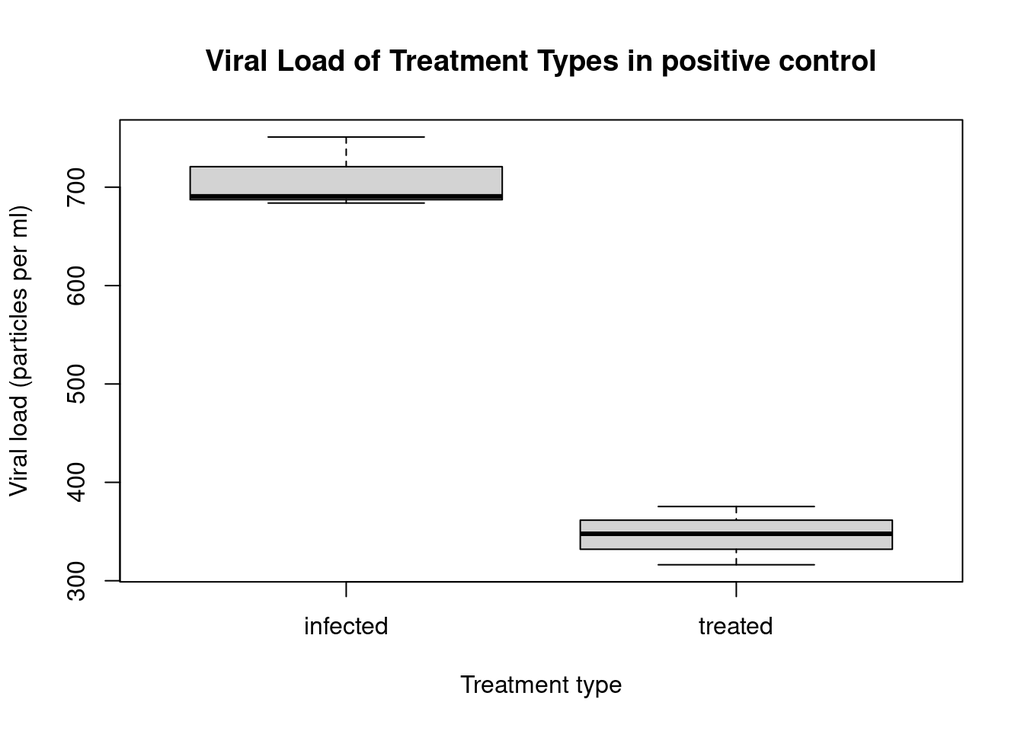

```r
#create a boxplot by sorting viral load according to treatment type in positive control
boxplot(viral.load.pos~treatment.type,

        #names of x and y axis
        xlab = "Treatment type",
        ylab = "Viral load (particles per ml)",

        #name of title axis
        main = "Viral Load of Treatment Types in positive control")
```

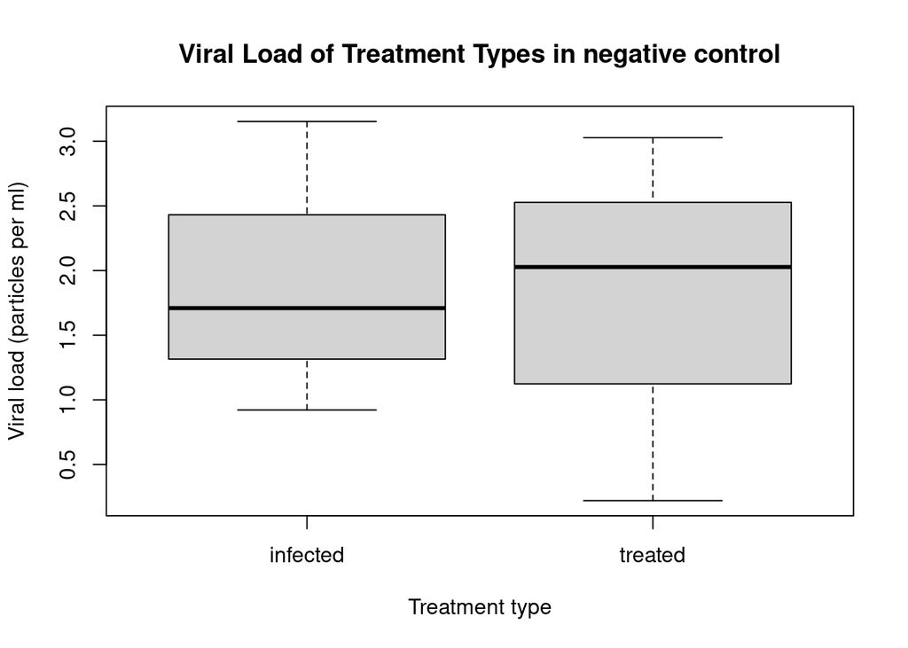

```r
#repeat procedure for negative control
boxplot(viral.load.neg~treatment.type,
        xlab = "Treatment type",
        ylab = "Viral load (particles per ml)",
        main = "Viral Load of Treatment Types in negative control")
```

Although the boxplots provide a convenient visual summary, in order to obtain discrete values for comparison, t-tests are conducted. This is also undergone for each of the candidate viruses to infer the validity of VK001 as a treatment.

The p-values from the t-tests are added as a separate column in the main dataframe.

```r
#creating a new dataframe with all non-numeric variables eliminated, this would generate infected values in columns 1-3 and treated in 4-6
main.numeric <- main[,-1:-2]


#creating a function for t-testing columns 1-3 and 4-6
t.testfor3 <- function(x){
  x1 = x[1:3]
  x2 = x[4:6]
  t.test(x1,x2, alternative="greater", type="paired")$p.value
}

#applying above function to each row in main.numeric
pval <- apply(main.numeric,1,t.testfor3)

#adding p-values as an additional column in main
main = cbind(main, pval)

main
```

|  | Virus_Class | Host_Organism | Infected_1 | Infected_2 | Infected_3 | Treated_1 | Treated_2 | Treated_3 | pval |
| --- | --- | --- | --- | --- | --- | --- | --- | --- | --- |
| Coronavirus_SARS_ab1 | Coronavirus | human | 751.0155 | 690.6944 | 683.8702 | 347.7364 | 316.2450 | 375.4223 | 0.0001240839 |
| Coronavirus_SARS_negative | Coronavirus | human | 0.9214 | 1.7095 | 3.1532 | 0.2205 | 3.0275 | 2.0273 | 0.4399214645 |
| Influenza_porcine_x1 | Influenza | porcine | 701.8708 | 677.2102 | 681.2646 | 826.1171 | 716.8273 | 624.4835 | 0.6981981881 |
| Norovirus_porcine_f29 | Norovirus | porcine | 753.2343 | 724.6823 | 702.9480 | 740.1410 | 656.5205 | 685.0600 | 0.1623605275 |
| Influenza_avian_b4 | Influenza | avian | 787.6892 | 712.9360 | 716.1853 | 808.7388 | 792.3312 | 724.4397 | 0.8172968318 |
| Influenza_porcine_y2 | Influenza | porcine | 505.7235 | 528.4356 | 563.0209 | 602.2051 | 577.8961 | 502.4395 | 0.7670204223 |
| Influenza_porcine_y5 | Influenza | porcine | 582.9782 | 608.5310 | 495.4271 | 614.2217 | 537.7795 | 700.2593 | 0.7994051291 |
| Coronavirus_bat_b11 | Coronavirus | bat | 717.7689 | 667.7027 | 692.9803 | 352.2365 | 241.8179 | 330.2213 | 0.0014294885 |
| Circovirus_porcine_q13 | Circovirus | porcine | 611.5688 | 573.4611 | 633.0805 | 599.3610 | 596.8109 | 570.0904 | 0.2227231667 |
| Circovirus_porcine_q34 | Circovirus | porcine | 937.8734 | 895.4489 | 872.8864 | 970.0355 | 827.2766 | 875.2588 | 0.4122353781 |

[output cut: 38 more lines]

The Benjamini-Hochberg method is used to correct for multiple testing. The adjusted p-values are added to another column.

```r
#'BH' stands for Benjamini-Hochberg.
adj.pval<-p.adjust(pval, method = 'BH')

#adding adj.pval as additional column in main
main = cbind(main,adj.pval)

main
```

|  | Virus_Class | Host_Organism | Infected_1 | Infected_2 | Infected_3 | Treated_1 | Treated_2 | Treated_3 | pval | adj.pval |
| --- | --- | --- | --- | --- | --- | --- | --- | --- | --- | --- |
| Coronavirus_SARS_ab1 | Coronavirus | human | 751.0155 | 690.6944 | 683.8702 | 347.7364 | 316.2450 | 375.4223 | 0.0001240839 | 0.002978013 |
| Coronavirus_SARS_negative | Coronavirus | human | 0.9214 | 1.7095 | 3.1532 | 0.2205 | 3.0275 | 2.0273 | 0.4399214645 | 0.879842929 |
| Influenza_porcine_x1 | Influenza | porcine | 701.8708 | 677.2102 | 681.2646 | 826.1171 | 716.8273 | 624.4835 | 0.6981981881 | 0.999338092 |
| Norovirus_porcine_f29 | Norovirus | porcine | 753.2343 | 724.6823 | 702.9480 | 740.1410 | 656.5205 | 685.0600 | 0.1623605275 | 0.599297671 |
| Influenza_avian_b4 | Influenza | avian | 787.6892 | 712.9360 | 716.1853 | 808.7388 | 792.3312 | 724.4397 | 0.8172968318 | 0.999338092 |
| Influenza_porcine_y2 | Influenza | porcine | 505.7235 | 528.4356 | 563.0209 | 602.2051 | 577.8961 | 502.4395 | 0.7670204223 | 0.999338092 |
| Influenza_porcine_y5 | Influenza | porcine | 582.9782 | 608.5310 | 495.4271 | 614.2217 | 537.7795 | 700.2593 | 0.7994051291 | 0.999338092 |
| Coronavirus_bat_b11 | Coronavirus | bat | 717.7689 | 667.7027 | 692.9803 | 352.2365 | 241.8179 | 330.2213 | 0.0014294885 | 0.011435908 |
| Circovirus_porcine_q13 | Circovirus | porcine | 611.5688 | 573.4611 | 633.0805 | 599.3610 | 596.8109 | 570.0904 | 0.2227231667 | 0.668169500 |
| Circovirus_porcine_q34 | Circovirus | porcine | 937.8734 | 895.4489 | 872.8864 | 970.0355 | 827.2766 | 875.2588 | 0.4122353781 | 0.860317311 |

[output cut: 38 more lines]

The viruses that satisfy adjusted p-value < 0.05 are selected (excluding controls).

```r
#the which function may be used here, but the author has been obsessed with loops so a different approach is taken. The while loop is used this time.

#while an integer x is less than the number of rows in main, the corresponding function is performed repeatedly until the condition no longer holds true. x is set as 2 as to exclude the controls.
x <- 2
while (x < nrow(main)){

  #x increases by 1 for each repeat. Thus, eventually the condition will no longer hold true, escaping the loop. We can infer that the loop repeats for the number of rows in main.
  x <- x+1

  #the xth adj.pval is checked to see if it is less than 0.05. If so, this would imply that the drug has an effect for that virus and the row is printed.
  if (adj.pval[x] < 0.05){

    print(adj.pval[x])

  }

}
```

```
## Coronavirus_bat_b11
##          0.01143591
## Coronavirus_bat_e27
##         0.002978013
## Coronavirus_bat_m42
##         0.003699032
## Coronavirus_chicken_k12
##              0.01143591
## Coronavirus_porcine_c6
##             0.01052082
```

The null hypothesis can be rejected only for the above 5 viruses with p < 0.05.

According to this study, VK001 seems to be effective only on coronaviruses, but to see if this effect is exhaustive on all coronaviruses, the number of coronaviruses in main is obtained as such:

```r
#converting Virus_class to character, which enables its use in if statements (comparing factors just wasn't working)
main$Virus_Class <- lapply(main$Virus_Class, as.character)
#creating vector to store the number of coronaviruses
coronavirus.total <- c()

#repeat for each row in main, excluding the controls
for (x in 3:nrow(main)){

  #if the viral class is coronavirus,
  if (main$Virus_Class[x] == "Coronavirus"){

    #add an element to coronavirus.total
    coronavirus.total <- c(coronavirus.total, "Coronavirus")
  }
}

#print the number of elements in coronavirus.total
length(coronavirus.total)
```

```
## [1] 5
```

The total coronaviruses in main is 5, and we obtained 5 viruses that VK001 is effective on. At least for this study, it seems that VK001 has an effect on all coronaviruses, and those only. Boxplots are generated to directly compare the effect of VK001 on the different types of viruses.

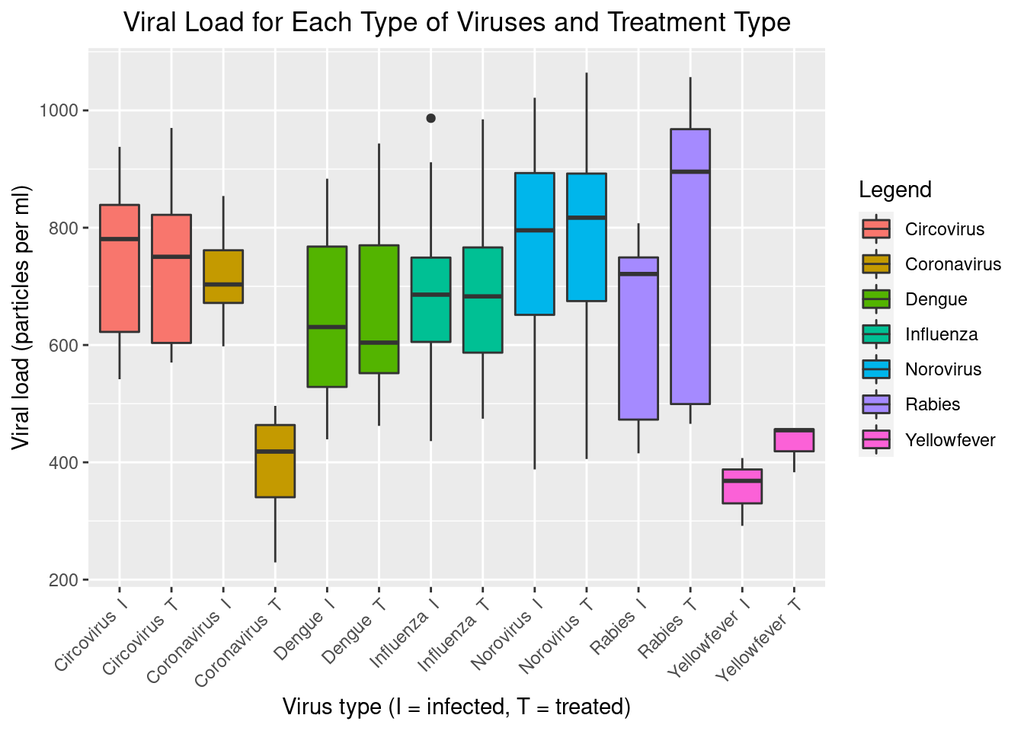

```r
#vector of characters for comparing with Virus_Class column in main
virus.type <- c("Coronavirus", "Influenza", "Norovirus", "Circovirus", "Dengue", "Rabies", "Yellowfever")

#vector for viral loads
virus.load <- c()

#vector for type of virus and whether it's infected or treated
category <- c()

#vector for type of virus (regardless of infected or treated), this can be used to color the graph accordingly as will be shown below
Legend <- c()

#for each type of viruses
for (x in 1:7){

  #for each row in main (excluding first 2 as they're controls)
  for (y in 3:nrow(main)){

    #cycle through each row in main to see if they match the type of virus in the overarching loop. If so, perform the function within:
    if (virus.type[x] == main$Virus_Class[y]){

      #take the columns 3 to 5 of main, which contains infected replicates
      for (z in 3:5){

        #incorporate the corresponding viral load into vector
        virus.load <- c(virus.load, main[y,z])

        #declare type of virus and concatenate it with either I or T (I in this case), to show if it's infected or treated condition. incorporate into vector.
        category <- c(category, paste(virus.type[x], " I"))

        #incorporate the type of virus (without identifying treatment type) into vector
        Legend <- c(Legend, virus.type[x])
        }

      #take the columns 6 to 8 of main, which contains treated replicates
      #repeat above procedure
      for (z in 6:8){

        virus.load <- c(virus.load, main[y,z])
        category <- c(category, paste(virus.type[x], " T"))
        Legend <- c(Legend, virus.type[x])

      }
    }
  }
}

#incorporate the vectors into one dataframe
main4 <- data.frame(category, virus.load, Legend)


#The ggplot2 package downloaded beforehand is used. Note beginning of document.

#The dataset and the plane for the graphs to be plotted on are specified here. Graphs and titles can then be added as layers using the + sign as shown below.
ggplot(main4, aes(x = category, y = virus.load, fill = Legend)) +


  #creates titles for the graph and x/y axis
  labs(x = "Virus type (I = infected, T = treated)", y = "Viral load (particles per ml)", title = "Viral Load for Each Type of Viruses and Treatment Type") +

  #aligns title to center (default is left-aligned)
  theme(plot.title = element_text(hjust = 0.5)) +

  #tilts x-axis values to fit better in screen (by 45 degrees)
  theme(axis.text.x = element_text(angle = 45, hjust = 1)) +

  #creates boxplot
  geom_boxplot()
```

## Discussion

#### Comparing Controls

Boxplots are chosen as the treatment groups are being compared and not the individual values within each group.

A clear difference between the two conditions is observed for the positive control, with no overlaps. This suggests that the treatment had a significant effect on the viral load, which would make sense as it is already shown that VK001 can inhibit this type of virus (hence its usage as a positive control)

For the negative control, however, There are significant overlaps, suggesting that VK001 does not have an effect. However, the extremely small viral load should be noted, suggesting that rather than VK001 not having an effect, the virus failed to replicate. The genetic material was taken out here, hence enabling its usage as a negative control.

#### Correcting for Multiple Testing

The Benjamini-Hochberg method is used to control for the false negatives.

Due to the extremely small sample sizes used for each virus, it is highly unlikely that the viruses identified in this study will be directly used in clinical trials. Further animal studies will need to be conducted before moving onto clinical trials, suggesting that false positives are less relevant here as the viruses will be going through additional studies anyways.

False negatives, however, are more impactful as potential treatments for the virus might be missed out. It is critical that all viruses which have the potential to be inhibited by VK001 are investigated.

Therefore, in order to control for the false negatives as much as possible, the Benjamini-Hochberg method was used to correct for multiple testing.

## Conclusion

The null hypothesis is rejected only for the coronaviruses as adjusted p<0.05. It is deemed that the probability of obtaining such results if the null hypothesis was true is too small, thus enabling its rejection.

Further tests would need to be conducted on other coronaviruses, but it can be suggested that VK001 binds to a specific genetic sequence present only in coronaviruses, inhibiting their replication.

```r
untreated <- c(2.4717, 2.5028, 2.2448)


t.test(c(2.1066, 2.3524, 2.4477), c(2.0976, 1.9785, 1.6882), alternative = 'greater')
```

```
##
##  Welch Two Sample t-test
##
## data:  c(2.1066, 2.3524, 2.4477) and c(2.0976, 1.9785, 1.6882)
## t = 2.4033, df = 3.8778, p-value = 0.03806
## alternative hypothesis: true difference in means is greater than 0
## 95 percent confidence interval:
##  0.03992713        Inf
## sample estimates:
## mean of x mean of y
##  2.302233  1.921433
```

```r
treatment = c('V', 1,2,3,4,5,6,7,8,9,10, 11)
firstrep = c(2.0098, 0.9075, 1.1853, 1.9809, 2.0976, 2.4005, 1.9008, 1.539, 2.0547, 2.0014, 2.1273, 1.6433)

secondrep = c(0.7751, 1.8664, 1.4697, 1.824, 1.9785, 1.7049, 1.7569, 1.7711, 1.5754, 2.2664, 2.3984, 2.0543)

thirdrep = c(1.1455, 2.1567, 1.8125, 1.8917, 1.6882, 1.6919, 1.9842, 2.0578, 1.4873, 1.8754, 2.3403, 2.1595)


firstrep <- rev(firstrep)
secondrep <- rev(secondrep)
thirdrep <- rev(thirdrep)

treatment.data <- data.frame(treatment, firstrep, secondrep, thirdrep)
treatment.data
```

| treatment | firstrep | secondrep | thirdrep |
| --- | --- | --- | --- |
| V | 1.6433 | 2.0543 | 2.1595 |
| 1 | 2.1273 | 2.3984 | 2.3403 |
| 2 | 2.0014 | 2.2664 | 1.8754 |
| 3 | 2.0547 | 1.5754 | 1.4873 |
| 4 | 1.5390 | 1.7711 | 2.0578 |
| 5 | 1.9008 | 1.7569 | 1.9842 |
| 6 | 2.4005 | 1.7049 | 1.6919 |
| 7 | 2.0976 | 1.9785 | 1.6882 |
| 8 | 1.9809 | 1.8240 | 1.8917 |
| 9 | 1.1853 | 1.4697 | 1.8125 |

[output cut: 2 more lines]

```r
p_values <- c()
significance <- c()
pvalue_adjusted <- c()

for(x in 1:nrow(treatment.data)){
  pvalue = t.test(c(2.1066, 2.3524, 2.4477), treatment.data[x,2:4], alternative = 'greater')$p.value
  p_values <- c(p_values, signif(pvalue, digits = 5))
  pvalue_adjusted<- c(pvalue_adjusted, signif(p.adjust(pvalue, method = 'bonferroni'), digits = 3))

  if (pvalue < 0.05){
    significance <- c(significance, 'yes')
  }
  else {
    significance <- c(significance, 'no')
  }


}

data.all <- data.frame(treatment, pvalue_adjusted, significance)
data.all
```

| treatment | pvalue_adjusted | significance |
| --- | --- | --- |
| V | 0.0737 | no |
| 1 | 0.4610 | no |
| 2 | 0.0870 | no |
| 3 | 0.0282 | yes |
| 4 | 0.0275 | yes |
| 5 | 0.0162 | yes |
| 6 | 0.1260 | no |
| 7 | 0.0381 | yes |
| 8 | 0.0206 | yes |
| 9 | 0.0136 | yes |

[output cut: 2 more lines]

```r
firstre = c(1.7021, 2.2137, 2.2488, 2.3945, 2.1825, 2.5042, 2.211, 2.4914, 2.4316, 2.3187, 2.2084, 2.1487)
secondre = c(2.123, 2.3798, 1.9983, 2.3192, 2.3066, 2.4805, 2.5525, 2.5003, 2.3813, 2.457, 2.0812, 2.0404)
thirdre = c(2.4336, 2.4588, 2.1459, 2.3683, 2.3688, 2.7332, 2.4772, 2.311, 2.2192, 2.4153, 2.4228, 2.1436)
```